# HSMA Content Writing Manual

Author

Sammi Rosser

Published

February 11, 2026

# Introduction

This is a guide to writing content for HSMA sessions.

It contains tips, tricks, useful things to know about students, lessons learned from what’s gone well and not so well, and more.

# Designing a HSMA Day

## How an HSMA Day Runs

HSMA days run from 09:30 - 16:30, with a 1 hour break for lunch between 12:30 and - 13:30.

You therefore effectively have two main 3 hour blocks of teaching to fill with a mixture of lectures, group exercises, and discussions.

**Tip**

We’d generally set an upper limit of 1 hour on any single lecture section.

30 - 45 minutes is a better target where possible.

**Tip**

Don’t forget to leave time for breaks! Across a 3 hour morning section, I like to give at least one 10 minute break, and a 5 minute ‘comfort break’ as well if the sessions allow. This is a minimum - give 20 minutes total if you have breathing room.

### Schedules

We always provide a schedule to students ahead of time.

**NoteClick here to view some sample itineraries**

This is an example of one of Dan’s sessions.

[interactive chart not shown]

This is an example of one of Sammi’s sessions.

[interactive chart not shown]

## Group work in HSMA

HSMAs are placed into ‘peer support groups’ (PSGs) when they start on the programme and, for the most part, will stay with the same PSG throughout.

In HSMA 7, we are giving students more control over how they prefer to work.

|  | Option A | Option B |
| --- | --- | --- |
| **Group make-up** | A more varied level of prior knowledge | A more similar level of prior knowledge |
| **Working style** | Primarily individually, each on their own copy of an exercise, but working as a group to make sure everyone is progressing and to answer questions | Primarily collaboratively, all working on a single copy of the exercise together |

Together, these give four possible combinations:

|  | **Varied prior knowledge** | **Similar prior knowledge** |
| --- | --- | --- |
| **Individual working** | Mixed-experience group, each working on their own copy | Similar-experience group, each working on their own copy |
| **Collaborative working** | Mixed-experience group, working together on a single copy | Similar-experience group, working together on a single copy |

**NoteReminder - Prior level of student knowledge**

HSMA is aimed at people with a wide range of backgrounds, from those with no prior computer programming experience all the way up to experienced python programmers with significant prior knowledge in areas such as statistics but who have perhaps not dabbled in operational research or machine learning previously.

Therefore, exercises need to provide something for all of those people! This can be challenging but is achievable, and later parts of this section expand on some ways you can support this.

Read more about the pacing and prior level of knowledge in this section.

## Types of Group Exercises

**Tip**

It’s generally not worth putting students into their groups for less than about 30 minutes, due to the overhead associated with getting them into their breakout rooms.

### Code Exercises

A large number of exercises in HSMA will involve getting students to work on some code.

#### Working in Python Compiler

Early sessions make use of https://pythoncompiler.io/

**Note**

See the HSMA tech stack page for more information about how students are expected to work on sessions.

#### Working from a given .py file

Here are some examples:

- Exercise 1 in HSMA 6 5C (sentiment analysis)
  - [Slides: exercise 1, slide 30](https://docs.google.com/presentation/d/1k2gQkA6Qa0TKm47Hh6tM7heTpYh6w2wF27ImQC_BeXk/edit?usp=sharing)
  - [Code](https://github.com/hsma-programme/h6_5c_sentiment_analysis/blob/main/5c_sentiment_analysis/sa_1.py)

#### Working from a given notebook

You may wish to give students a notebook they can work from.

There are lots of examples of this in HSMA 6 module 3:

- Exercise 1 in HSMA 6 3C:
  - [Slides: exercise 1, slide 28](https://docs.google.com/presentation/d/1Xj9jYaJ_FH7ko84DGJ2M1l4DWfJ-W5wmY906UkUEgRg/edit?usp=sharing)
  - [Notebook](https://github.com/hsma-programme/h6_3c_interactive_plots_travel/blob/main/h6_3c_interactive_plots_travel/exercises/HSMA%203C%20Exercise%201%20-%20Interactive%20Plots.ipynb)

#### Starting from scratch

Students may also be given instructions where they are expected to write a .py file, .qmd file, notebook, streamlit app, or other kind of artefact from scratch. Alternatively, in sessions relating to tools like Git, they may not be writing code as an artefact, but it’s along the same lines.

Here are some examples:

- Writing a py file from scratch in HSMA 6 2C SimPy Part 2
  - [Slides: exercise 1, slide 25](https://docs.google.com/presentation/d/1y7S7bjJtdLQCquzzZ2vjYzRx9-RwXE-SWgWf88fLc4o/edit?usp=sharing)
- Writing a .qmd file using a given .py file in HSMA 6 8A Quarto
  - [Slides: exercise 1, slide 57](https://docs.google.com/presentation/d/1XYMK5b4dNaHfVesHO2EvRn1j2lFgQULadbRUU5FCkDg/edit?usp=sharing)

### Design Exercises

In some cases, there may be design-based exercises where students plan something like a DES model by hand, with no code written.

Here are some examples:

- Design a Discrete Event Simulation for a system of your choosing
  - [Slides: exercise 1, slide 19](https://docs.google.com/presentation/d/1HO0wXTocHRZgeuLadkGvqf5yC8BEmQzTcgo8QHOd0yY/edit?usp=sharing)
- Design a ML model by hand to classify Dan’s desert island DVDs
  - [Slides: exercise 2, slide 33](https://docs.google.com/presentation/d/1EcO71B5kEvaSkvKQeGnuO2g4Ss4RKhrphR3gE8vv-Gk/edit?usp=sharing)

### Discussion Exercises

You may wish to get students to discuss a topic and report their findings back to the wider group.

You should consider ways to make the discussion inclusive (e.g. encouraging the use of zoom whiteboards or similar features so people can contribute points as post-it notes).

### Interactive Tool Exercises

We have several interactive tools available on HSMA that can form part of teaching.

**Note**

Check whether each is hosted on stlite (in which case it will have a .hsma or .github.io link) or on streamlit community cloud (in which case there will be streamlit.app in the URL).

stlite apps can be used by an unlimited number of users simultaneously.

Other apps need to be used cautiously as they are likely to exceed limits, so you may need to get students running them locally (and they don’t learn streamit until sessions 2h and 2g).

**DES**

- [The full DES playground](https://github.com/hsma-programme/Teaching_DES_Concepts_Streamlit)
- [The mini DES playground](https://github.com/hsma-programme/des_playground_mini)
- [Interactive vidigi exercise and playground](https://github.com/hsma-programme/nhs_oa_vidigi_streamlit)

**Geographic**

- [The full geographic decision-making roleplay](https://github.com/hsma-programme/geographic_or_ds_playground)
- [The mini geographic playground](https://github.com/hsma-programme/geographic_playground_mini)

**Machine learning**

- [The ‘commissioner’ ML readmission model sign-off roleplay](https://github.com/hsma-programme/lambda_ml_streamlit_exercise)
- [The mini ML playground](https://github.com/Bergam0t/ml_playground_mini)
- [The reinforcement learning game](https://github.com/Bergam0t/ReinforcementLearningGame)

You might also consider using other online sites that support a particular point - e.g. https://thetruesize.com/ as part of a larger exercise on map projections

## Other Types of Exercises

### Short Interactive Solo Exercises

To keep participants engaged, it can be helpful to scatter small interactive exercises into longer lecture sections.

#### Zoom Poll

We can’t easily use Zoom’s built-in polls due to Zoom limitations: only the host (Dan) can create them in advance and launch them, and transfer of host or co-host responsibilities within the Zoom app doesn’t help.

Therefore, it’s recommended to use Menti instead.

[Zoom poll documentation](https://support.zoom.com/hc/en/article?id=zm_kb&sysparm_article=KB0066150)

#### Menti

Menti supports small interactive polls. Through the university of Exeter, we have access to a paid Menti account if you sign in with SSO.

There are two key types of Menti polls:

- survey (self-paced)
- presentation (presenter controls progression through questions)

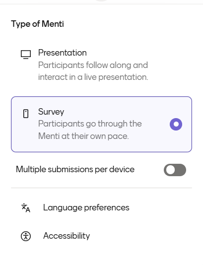

In HSMA, we tend to use ‘survey’, though ‘presentation’ may be appropriate in certain circumstances (but is generally a bit more challenging for the trainer to juggle alongside presenting slides).

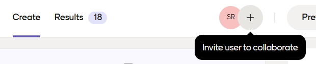

##### Setting up Menti Polls

We have a built-in HSMA theme we can provide access to (but we’ll need your email address to do that).

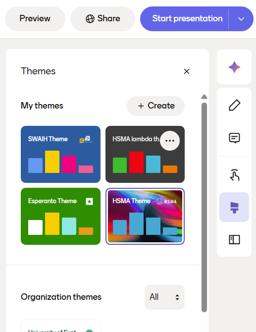

You will need to provide editor access to any Menti polls to both Dan (d.chalk@exeter.ac.uk) and Sammi (s.j.rosser@exeter.ac.uk) using the ‘invite user to collaborate’ button.

For all questions, consider whether you want to hide participant responses until the trainer clicks, so that users aren’t influenced by other participant’s answers.

You can do this per question by choosing the edit button while the question is selected.

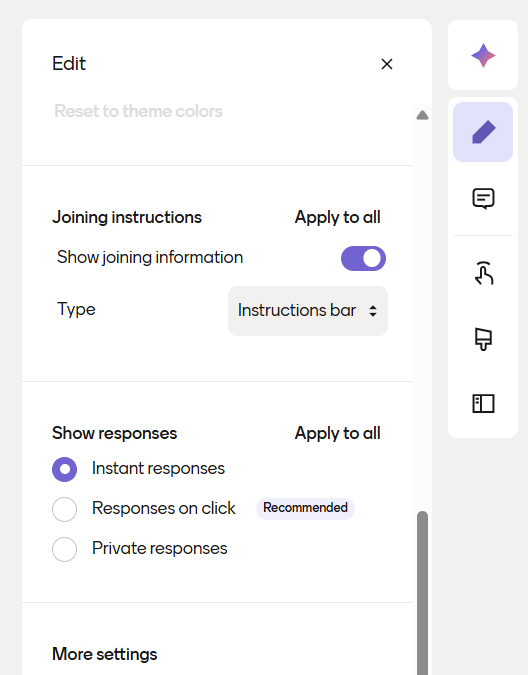

##### Sharing Menti Polls with Participants

Note that Menti join codes expire after only a few days (currently the maximum that can be set is 14 days), but QR codes and the menti URL for the poll do not expire, so can be set up well in advance.

Therefore, it’s best to provide a slide with the QR code and the url (but not the access code). The trainer can then also paste the URL into the session on the day.

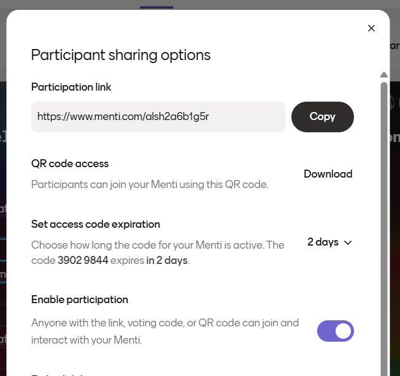

##### Sharing Menti Poll Results

**Quarto**

If you are using Quarto slides, you can integrate the results page directly into the slides, so you can see the responses without having to navigate elsewhere

To embed into your Quarto slides, get the ‘embed slides’ link from the participant sharing options (accessed by clicking ‘share’).

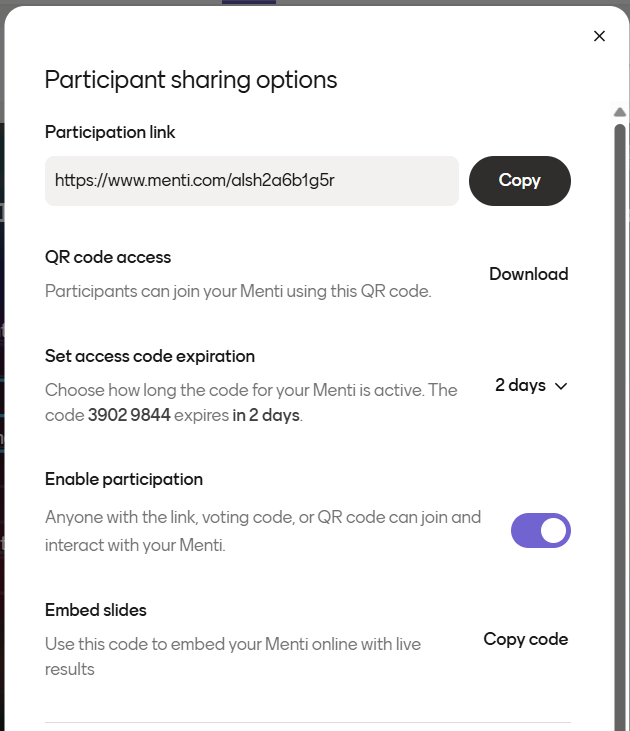

This will give you a block like the below that you can copy in to your Quarto slides.

[video not shown]

**Google Slides**

If using google slides, just copy the long mentimeter link into the slides. In the participant sharing options, make sure the Access Level is set to ‘Limited’.

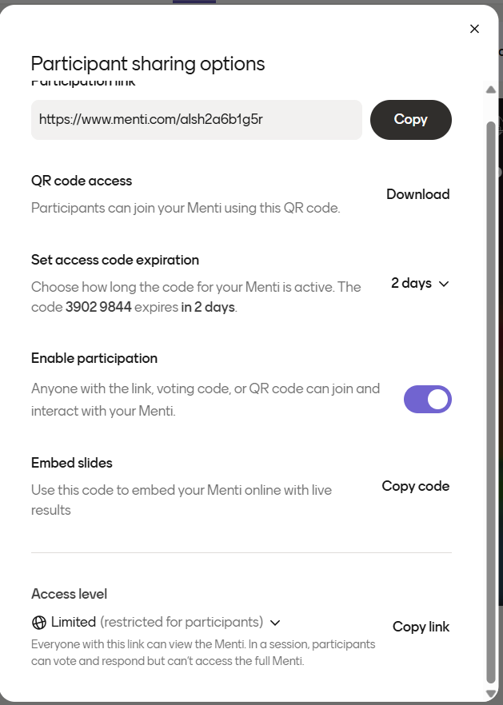

# Prior Knowledge and Pacing

## Prior Knowledge - before joining

HSMAs can come from a wide variety of backgrounds.

A large number join with **zero** prior programming knowldge.

However, you will also get

- people with extensive R knowledge but limited or no Python experience
- people with a small amount of prior R or Python experience
- people (usually analysts) who have used complex Excel and SQL, but have not used a language like R or Python before.

HSMAs can be

- analysts working in the NHS or related organisations
- clinicians
- managers
- GPs

There are no particular entry requirements for HSMA beyond a self declaration of a reasonable level of computer literacy. We do not expect students to have any particular mathematical, statistical, or other knowledge.

Therefore, sessions have to be designed with this diversity in mind; you will often need to cover the foundations in significant detail.

**Tip**

In HSMA, we do not necessarily shy away from explaining more technical thing - but it’s important to consider creative approaches to doing so, like games, analogies, etc.

However, in some cases, it may also be reasonable to keep a technical explanation extremely simplified or high level. The main goal is to make students into safe, effective users of various techniques; if deep understanding of the technical underpinnings of a method is not necessary to achieve that, then consider skipping it in favour of spending more time on potential pitfalls.

## Prior knowledge - on the programme

To see what people have learned prior to the session you are writing, take a look at it in the flow of the [draft HSMA 7 syllabus](https://docs.google.com/spreadsheets/d/1k14aCL4ON5AFZ9hlGZOcLwkemSYUcZlfyF-tDH3zUQw/edit?usp=sharing).

For a more detailed breakdown of what has been taught in every session up to that point, take a look at the [HSMA 7 Modules - What’s Covered](https://docs.google.com/document/d/1tciVsdtEZvKJd_uoWP-TU1gml8XdRzCvVU1drZMfLdk/edit?usp=sharing) document.

Speak to Sammi or Dan if you have any issues with accessing the file at that link.

## Pacing

The general gist for HSMA pacing is ‘go a lot slower than you think you need to’.

*To be expanded*

# Designing HSMA Slides

## Tooling

There are two primary options for making your slides:

1. Google Slides
2. Quarto

### Google Slides

Google Slides was used throughout HSMA 6.

**Pros**

- Quick and easy to create
- Lots of flexibility in layout
- Printable/PDF version tends to create well

**Cons**

- Navigation can be challenging for students due to lack of table of contents
- The Google suite (Slides, Docs, Sheets) is blocked on *some* NHS networks
- As code is generally pasted in as screenshots
  - updates can be more time-consuming
  - accessibility is reduced as screen-readers cannot consume this
- Cannot integrate Menti directly

Template: https://docs.google.com/presentation/d/1XbmXo6tz9TfjCmAj9qSRXVA7x15IojkBz3IfdLqZgbI/edit?usp=sharing

Examples can be found throughout the HSMA 6 content: hsma.co.uk/modules

### Quarto

Quarto is a publishing platform allowing you to create rich outputs by writing in markdown.

**Pros**

- Provides an automated table of contents (addressing student feedback that it can sometimes be difficult to find the right sections in a google slides output when working on exercises or referring back to it)
- Easy to make a change across all code examples if you spot an issue or make a change to how you do things (avoiding copying and pasting or re-screenshotting)
- Can include interactive elements (charts, embedded iframes from other sites such as Menti, streamlit apps, live code windows where things can be rerun)
- Wide range of extensions gives you a lot of flexibility (e.g. focus-list allows you to create an incrementally-revealing list where previous points are dimmed as the next appears, reducing cognitive load)

**Cons**

- Generally significantly more time-consuming to create
- Less layout flexibility (and frustrating to work on layouts in)
- Occasional very obscure bugs that are time-consuming to resolve
- Requires you to host the end product (though github pages makes this pretty easy)
  - In addition, due to choice of extensions in our template, we can’t bundle it as a single HTML file, making distribution more challenging
- PDF output is often not as good as in Google Slides
- GitHub pages (where we tend to host) is blocked on *some* NHS networks

## Theory of Slides

Dan and I come at slides from two different angles - you may also have a preferred approach!

**Sammi: Primarily a Teaching Aid**

- Keeping the information per slide to a minimum to reduce extraneous cognitive load
  - In addition, lots of incremental reveals on slides and highlighting to keep student’s focus on the current point
- Not as easy to refer back to; work best when combined with an [eBook](https://hsma.co.uk/books)

**Dan: Combined teaching aid and reference material**

- May have significantly more text per slide
  - so possibly an increase in extraneous cognitive load
- Slides stand alone strongly as reference material

## Hints and Tips for Quarto Slides

The tips below are drawn from the HSMA 7 session 2F deck (*Animaniacs: bringing your simulations to life with vidigi*), which was built on the [HSMA Quarto slide template](https://github.com/hsma-programme/hsma_quarto_slide_template).

Most of them work in the template as it is. Where a tip needs something extra, that’s noted alongside it.

### Organising your deck

#### Split the deck into section files

Rather than writing one very long `slides.qmd`, put each part of the session in its own `_SECTION_*.qmd` file and pull them into the main deck with `include`:

```markdown
{{< include _SECTION_intro_to_animations.qmd >}}

{{< include _SECTION_what_is_vidigi.qmd >}}

{{< include _SECTION_vidigi_exercise_1.qmd >}}
```

This makes it easy to reorder the session, find the slide you’re looking for, and reuse sections elsewhere. The 2F repo uses the same section files to build a second, shorter deck for an external workshop, using a [Quarto project profile](https://quarto.org/docs/projects/profiles.html).

#### Preview one section at a time

The template keeps all the format, plugin and filter settings in `_metadata.yml`, which Quarto applies to every file in the project. That means you can preview a single section on its own, with the full HSMA styling, without rebuilding the whole deck:

```bash
quarto preview _SECTION_vidigi_exercise_1.qmd
```

This is much faster than rendering the full deck every time you make a change, especially once the deck contains outputs from code.

**Warning**

If your `docs/` folder looks broken or is missing files after a render, check for a leftover `quarto preview` process before assuming something is wrong with your slides. A preview still running in the background can clash with a full render and silently delete files.

If running in positron or VSCode, you can just close the process by killing the relevant terminal. If that hasn’t done it, run `tasklist | findstr /i "quarto deno"` (windows) in a terminal to check, close any you find, and render again.

Mac/linux: `pgrep -afil 'quarto|deno'`

### Slide structure

Use `#` headings for sections and `##` headings for slides. The template shows each section as a vertical stack, with dots on the right-hand side so students can see where they are within it.

For a slide without a visible title (such as an exercise slide), give it a name for the slide menu using the following syntax so it can still be found easily:

```markdown
## {.slide data-menu-title="Vidigi Exercise 1"}
```

Slides covering an interesting tangent can be marked with “BONUS:” at the start of the title, so students know they’re optional.

### Exercise slides

The 2F exercise slides follow a consistent layout that you may wish to copy:

- **The file to work in**, given by its path (e.g. `exercises/exercise_1.py`), with a sentence on what it contains.
- **How long they have**, in a value box with a clock icon (e.g. “45 minutes + 10 minute break”).
- **The core tasks** as a numbered list, with small greyed-out hints after any tricky steps.
- **Extension tasks** in a second column that only appears when you click, in smaller grey text. This gives faster students more to do without overwhelming everyone else.

```markdown
:::: {.columns}

::: {.column width='60%'}
::: {style='font-size: 75%;'}
You will be working with the file `exercises/exercise_1.py`.
:::
:::

::: {.column width='30%'}
::: {.value-box icon="fa-solid fa-clock" icon-position="left" icon-size="2em" min-height="60px" font-size="0.8rem"}
45 minutes <br>+ 10 minute break
:::
:::

::::

:::: {.columns}

::: {.column width='60%'}
::: {style='font-size: 70%'}
1. Add a logger
1. Add the required logging steps [(I'd recommend just using queues to start with)]{style="color:lightgrey;font-size: 65%"}
:::
:::

::: {.column width='40%'}
::: {.fragment}
::: {style='font-size: 65%; color: lightgrey'}
### Extensions

- Try changing the number of resources.
:::
:::
:::

::::
```

### Text

- **Highlighting key terms**: make a new term stand out where it’s introduced, e.g. `[**Directly Follows Graph**]{style="color:yellow"}`.
- **Asides**: put extra detail in small grey text so it doesn’t compete with the main point, e.g. `[(easier than it sounds - 1 line of code!)]{style="color:lightgrey"}`.
- **Supporting text**: wrap longer explanations in `::: {style='font-size: 75%;'}` so the slide’s main point stays the largest thing on it. If you find yourself shrinking everything, consider splitting the slide in two instead.
- **Spacing**: `<br>` adds a line of space. For a smaller gap, wrap it in a reduced font size: `::: {style='font-size: 35%;'}` then `<br>` then `:::`.

### Revealing content step by step

- **Fragments**: wrap anything in `::: {.fragment}` to reveal it on the next click. Add `.fragment` to a `.columns` block to reveal a whole row at once: `:::: {.columns .fragment}`.
- **Focus lists**: wrap a bullet list in `::: {.focus-list}` and each point appears in turn, with earlier points dimmed so attention stays on the current one. This is great from a cognitive load perspective, keeping people focussed on the point currently being talked about.
- **Before and after images**: put two images in an `.r-stack` and make the second a fragment. It appears on top of the first, in the same place.

```markdown
::: {.r-stack}
![](assets/vidigi_no_features.png){.lightbox height=600}

![](assets/vidigi_with_features.png){.fragment .lightbox height=600}
:::
```

### Value boxes

The 2F deck uses value boxes in a few consistent ways, so students quickly learn what each kind means:

| Purpose | Settings |
| --- | --- |
| Tip | `icon="fa-solid fa-lightbulb"`, `color="bg-green"` |
| Warning | `icon="fa-solid fa-triangle-exclamation"`, `color="bg-red"` |
| Time for an exercise | `icon="fa-solid fa-clock"` |

Some other useful tricks:

- Add `fragment="fade-in"` to a value box to reveal it on the next click. This works well for a tip that follows on from an explanation.
- Put several boxes side by side in a `::: {.value-box-row}`, for example to list three benefits of a technique.
- Make a box a link with `href` and `target="_blank"`. A row of these makes a good “Further Reading” slide.
- To centre a single box, wrap it in `<div style="display: flex; justify-content: center; align-items: center;">` and a closing `</div>`.

See Colours and Fonts for which value box colours to use.

### Images

Add `.lightbox` and a fixed height to images: `![](assets/example.gif){.lightbox height=500}`. The fixed height stops large images spilling off the slide, and students can click the image to see it full size.

GIFs work well for showing something in motion, such as an animation or an app being used.

### Code

#### Show which file the code belongs in

Wrap code in a `codewindow`, with the file name as the first line. It appears as a tab at the top of the window, so students always know which file you’re talking about.

````markdown
::: {.codewindow .python}
b_simple_one_step_model_vidigi.py
```python
import simpy
```
:::
````

#### Highlight the lines that matter

When walking through changes to existing code, dim the lines that haven’t changed and highlight the new ones with `code-line-style`. Marking new lines with a `# NEW` comment helps too, and `...` can stand in for code that hasn’t changed.

````markdown
```{.python code-line-style="dim:1-3,focus:4-5" code-line-style-preset="emphasis"}
import simpy
from sim_tools.distributions import Exponential, Lognormal
import pandas as pd
from vidigi.logging import EventLogger  # NEW
from vidigi.utils import create_event_position_df, EventPosition  # NEW
```
````

Code blocks have a maximum height by default, and scroll if the code is any longer. For a long piece of code that you want to show in full, such as a summary of a whole function, add the `.full-height-code` class to the code window:

````markdown
::: {.codewindow .python .full-height-code}
c_simple_one_step_model_vidigi_resources.py
```python
def attend_clinic(self, patient):
    ...
```
:::
````

Check the slide afterwards to make sure the code still fits. If it doesn’t, consider splitting it across two slides or using the smaller font div trick mentioned elsewhere in this section.

### Including outputs from code

The template sets `eval: false`, so code is shown on slides but not run. To show the output of some code instead, turn it on for that cell only, and optionall hide the code with `echo: false`:

````markdown
```{python}
#| eval: true
#| echo: false
#| label: every-1-min-time-size

from sample_code.c_simple_one_step_model_vidigi_resources import Param, Model
...
```
````

- **Import from the students’ files** where you can, as above, so the outputs on your slides come from exactly the code students have been given. See Walking through code, then showing its output below for a full example.
- **Give every executed cell a `label`.** It makes errors much easier to track down.
- **Freeze outputs.** The template sets `freeze: auto`, so cells are only re-run when their code changes, which keeps renders quick.
- **Put calculated numbers in your text** with inline code, e.g. `` Time to generate: `{python} round(animation_time_1, 2)` seconds ``. The figures then stay correct if something else changes.

#### Walking through code, then showing its output

The 2F deck walks students through the changes to a model one step at a time, then shows the result of running it. The code students are given lives in a `sample_code/` folder in the session repository, and the slides use it in two different ways.

**Walkthrough slides show a typed-out excerpt of the file.** These aren’t run. Each one shows just the part of the file being discussed, in a code window named after the file, with `code-line-style` highlighting the new lines and `...` standing in for code that hasn’t changed:

````markdown
## Generating the Animation

::: {.codewindow .python}
b_simple_one_step_model_vidigi.py
```{.python code-line-style="dim:1-3,focus:4-7,dim:8,focus:9" code-line-style-preset="emphasis"}
...
layout = create_event_position_df(...)

fig = my_model.logger.animate_activity_log(
    event_position_df=layout,
    every_x_time_units=1,
)

fig.show()
```
:::
````

**Output slides import the real file and run it.** The cell is hidden with `echo: false`, so students only see the result, and it imports the `Param` and `Model` classes from the same file students have been given:

````markdown
## The animation

```{python}
#| eval: true
#| echo: false
#| label: first-simple-animation

from IPython.display import HTML
from sample_code.b_simple_one_step_model_vidigi import Param, Model
from vidigi.utils import create_event_position_df, EventPosition

my_params = Param()
my_model = Model(my_params)
my_model.run_model()

# Layout is defined inside the `if __name__ == "__main__":` block of
# b_simple_one_step_model_vidigi.py, so it can't be imported - keep this
# copy in sync with that file
layout = create_event_position_df([...])

fig = my_model.logger.animate_activity_log(
    event_position_df=layout,
    every_x_time_units=1,
    plotly_height=600,
    plotly_width=1180
)

HTML(fig.to_html(full_html=False, include_plotlyjs="cdn", auto_play=False))
```
````

This means a fix to the model only needs making once, in the students’ file, and the outputs on the slides update the next time the deck is rendered.

For the import to work:

- The folder needs an empty `__init__.py` file in it (e.g. `sample_code/__init__.py`), so Python treats it as a package.
- Code runs from the project’s root folder (the template sets `execute-dir: project`), so imports are written relative to the root, as above.
- Anything inside the file’s `if __name__ == "__main__":` block can’t be imported. In the 2F deck, this was the animation layout, so it’s copied into the cell with a comment saying to keep the two in sync.

Note that the walkthrough excerpts **aren’t** linked to the file, so if you change the model, check the walkthrough slides still match.

**Tip**

If you want to show a whole short file rather than an excerpt, you can pull it in with `include` instead of typing it out. This works inside a code window, and alongside `code-line-style`:

````markdown
::: {.codewindow .python}
code_example_1.py
```{.python code-line-style="dim:1-3,focus:4" code-line-style-preset="emphasis"}
{{< include code_examples/code_example_1.py >}}
```
:::
````

The line numbers in `code-line-style` refer to lines of the file, so check the highlighting still lines up whenever the file changes.

#### Animated plotly figures

To include an animated Plotly figure, convert it to HTML:

```python
from IPython.display import HTML

HTML(fig.to_html(full_html=False, include_plotlyjs="cdn", auto_play=False))
```

Always include `auto_play=False`. The template then plays each animation automatically when you arrive on its slide, and pauses it when you leave. Without it, animations start playing as soon as their slide loads, before anyone can see them.

The template only loads the slides close to the one you’re on (`view-distance: 3` in `_metadata.yml`), so GIFs and animations further on don’t load early and slow the deck down.

### Embedding other websites

You can embed a live website, such as a tool you’re demonstrating, in an `iframe`:

````markdown
```{=html}
<iframe width='1200' height='625' src='https://embed.diagrams.net' title='Draw io'></iframe>
```
````

Always give the iframe a `title`, so screen-reader users know what it contains.

### Presenting

These keyboard shortcuts are useful while presenting:

| Key | What it does |
| --- | --- |
| `q` | Turns the mouse pointer into a laser pointer (and back) |
| `f` | Fullscreen |
| `s` | Speaker view, including any speaker notes |
| `Alt` + click | Zooms in on part of a slide (click again with `Alt` to zoom back out) |

Add speaker notes to a slide with a `::: {.notes}` block. They only appear in speaker view.

## Reporting Problems and Improving the Template

If you find a problem with the slide template, or something it should do but doesn’t, please let us know so that everyone benefits. Some examples are a bug, a layout that breaks, a colour that fails the contrast checks, or a missing feature.

There are two ways to do this:

1. **Open an issue** on the [slide template repository](https://github.com/hsma-programme/hsma_quarto_slide_template/issues). Describe what you were trying to do, what happened instead, and (if you can) include the few lines of Quarto that reproduce it. A screenshot helps for anything visual.
2. **Fix it yourself and submit a pull request.** Fork the repository, make the change on a new branch, and open a [pull request](https://github.com/hsma-programme/hsma_quarto_slide_template/pulls) explaining what you’ve changed and why. If it’s a bigger change, it’s worth opening an issue first so we can agree an approach.

**Tip**

Before opening a pull request, check that the template’s example deck (`slides.qmd`) still renders, and preview a single section to check that it still looks right. Where a change affects what’s described in this manual, it’s worth updating the relevant section here too.

## Extensions in the Slide Template

The slide template comes with a number of Quarto extensions already installed and switched on, so you can use them without any setup. Some are used throughout the template’s own example deck (`slides.qmd`), which is a good place to see them working.

Extensions come in two kinds, and which you’re using affects where they are switched on or off in `_metadata.yml`:

- **Plugins** are listed under `revealjs-plugins` (e.g. `verticator`, `pointer`, `codefocus`, `a11y`, `tabset`, `codewindow`).
- **Filters** are listed under `filters` (e.g. `stlite`, `reveal-header`, `bergam0t/value-box`, `bergam0t/focus-list`, `code-fullscreen`, `code-line-style`).

Value boxes, `code-line-style` and `codewindow` are covered in Hints and Tips for Quarto Slides above. The rest are described here.

### Focus lists

Wrap a bullet list in `::: {.focus-list}` and each point appears in turn, with the previous points dimmed. This keeps attention on the current point and reduces cognitive load. It also works with nested lists.

```markdown
::: {.focus-list}
* First important point
  * And a sub-point on that matter
* Second important point (previous one dims!)
* Third important point
:::
```

### Code focus

The `codefocus` plugin highlights particular lines of a code block as you step through fragments. This is useful when you want to talk through a block of code line by line.

Put a fragment with a `data-code-focus` attribute after the code block. When the fragment appears, the line numbers you give are highlighted. The `.current-only` class means that only the current fragment’s lines are highlighted at any one time.

````markdown
```python
answer = "42"
question = "What is the answer to life, the universe, and everything?"
print(f"Question: '{question}'\n Answer: '{answer}'")
```

::: {.fragment .current-only data-code-focus="1"}
When this fragment is shown, the first line of code is highlighted.
:::

::: {.fragment .current-only data-code-focus="3"}
Then this line when we move through.
:::
````

**Note**

`codefocus` steps through code using fragments, while `code-line-style` (covered above) fixes which lines are dimmed or highlighted when the slide appears. `code-line-style` is usually simpler when you just want to draw attention to the new lines in a block of code.

### Tabs

The `tabset` plugin lets you put alternative content on the same slide, with tabs to switch between them. This works well for showing the same thing done two ways, such as Google Slides and Quarto, or code alongside its output.

```markdown
::: {.panel-tabset}

### Code

Content for the first tab.

### Output

Content for the second tab.

:::
```

Each `###` heading inside the `.panel-tabset` becomes a tab. Add `tab-active=1` to the opening line, e.g. `::: {.panel-tabset tab-active=1}`, to start on a different tab (counting from 0).

### Interactive Streamlit apps

The `stlite` filter runs a Streamlit app directly in the slide, in the browser, with no server required. Use a `stlite-python` code block:

````markdown
```{stlite-python}
import micropip
await micropip.install("plotly")

import streamlit as st
from plotly import express as px

st.title("Sample App")

st.slider("Choose a number between 1 and 10", min_value=1, max_value=10, value=5)

st.plotly_chart(
    px.scatter(x=[1,2,3], y=[2,3,4])
)
```
````

Any package that isn’t built in needs installing with `micropip`, as for plotly above.

### Live code in the browser

The `live` extension (from `live-revealjs`, the format the template uses) lets you run Python in the browser. Use a `pyodide` code block, and students can edit and run it on the slide:

````markdown
```{pyodide}
import matplotlib.pyplot as plt
import numpy as np

x = np.random.normal(170, 10, 250)
plt.hist(x)
plt.show()
```
````

### Navigating and presenting

These extensions work automatically, with nothing to add to your slides.

| Extension | What it does |
| --- | --- |
| `verticator` | Shows a column of dots at the side of each section, one per slide in the section, so students can see where they are. Clicking a dot jumps to that slide. |
| `pointer` | Gives you a laser pointer. Press `q` to switch it on and off. |
| `fullscreen` | Press `f` to put the slides into fullscreen. |
| `code-fullscreen` | Adds a button to each code block that expands the code to fill the screen, useful for long code. |
| `reveal-header` | Puts the HSMA logo (from `logo:` in `_metadata.yml`) in the header and links it to hsma.co.uk. |
| `chalkboard` | Press `b` to draw on a blank chalkboard, or `c` to draw over the current slide. This is built in to Reveal.js and switched on in `_metadata.yml`. |

### Accessibility checks (a11y)

The `a11y` plugin adds a range of accessibility features to the slides, and is switched on in the template. These include:

- a settings menu (press `a`) with high contrast mode, font size and font family controls, and text spacing controls
- clearer focus outlines for keyboard users
- announcements of slide changes and fragments for screen readers

Two further checks are available, but are switched **off** by default in the template, as they can get in the way while you are building a deck:

- **Alt text warnings** highlight any image missing alt text
- **Link highlighting** underlines all links, so they’re not identified by colour alone

To switch either on while you are looking specifically at accessibility, change the setting in `_metadata.yml`:

```yaml
revealjs-a11y:
  high-contrast: false
  alt-text-warnings: true # highlight images missing alt text
  link-highlight: true # underline all links
```

If you’d rather turn the whole plugin off, comment out the `a11y` line under `revealjs-plugins`, and remove the `#` to switch it back on. The `revealjs-a11y:` settings are ignored while the plugin is off.

```yaml
revealjs-plugins:
  - verticator
  - fullscreen
  - pointer
  - codefocus
  # - a11y
  - tabset
  - codewindow
```

**Note**

We don’t currently rigidly enforce the use of alt text on images in HSMA slides. However, it’s good practice, and means that people using screen readers aren’t left out. Switch on `alt-text-warnings` from time to time to see which of your images are missing it, and add a short description to any you find: `![A diagram of the clinic process](assets/clinic.png)`.

Read more in Accessibility Considerations.

# Colours and Fonts

The [HSMA Quarto slide template](https://github.com/hsma-programme/hsma_quarto_slide_template) sets up the colours and fonts for you, so if you’re working in Quarto you shouldn’t normally need to change anything.

This section is for when you need to pick colours or fonts yourself - for example in Google Slides, in a diagram, or in a value box - so that your materials stay consistent with the rest of HSMA.

## Core colours

HSMA slides use light text on a dark background, with HSMA red as the accent colour.

|  | Colour | Hex | Where it’s used |
| --- | --- | --- | --- |
|  | HSMA red | `#8f0000` | Brand colour; the progress bar along the bottom of the slides |
|  | Background grey | `#303030` | Slide background behind the banner image |
|  | Content box grey | `rgba(56, 56, 56, 0.8)` | The semi-transparent box behind slide content, which lets the banner show through |
|  | White | `#ffffff` | All body text and headings |
|  | Link blue | `#42affa` | Links |
|  | Highlight yellow | `#FAEE42` | Alternate Link Colour, or highlighted text |

The slide backgrounds are the HSMA banner artwork (`assets/banner.png` on the title slide, `assets/banner_hq.png` on content slides) rather than a flat colour.

**Tip**

HSMA red is a good accent colour but a poor text colour on the dark background - its contrast ratio against `#303030` is only 1.4:1. Use it for fills and borders, with white text on top (9.7:1), rather than as coloured text.

## Title slide

The title slide puts a dark, semi-transparent panel over the banner, with two accent colours for the author and the tagline.

|  | Colour | Hex | Where it’s used |
| --- | --- | --- | --- |
|  | Author green | `#7ac943` | Author name |
|  | Tagline yellow | `#ffe600` | Tagline under the title |
|  | Panel black | `rgba(0, 0, 0, 0.45)` | Panel behind the title text |

## Value box colours

Value boxes come from the `bergam0t/value-box` extension, and you choose a colour with the `color` attribute (e.g. `color="bg-teal"`). Text in a value box is always white.

All of the extension’s own colours give white text a contrast ratio of at least 4.5:1, which meets the WCAG AA standard for normal-sized text.

|  | Class | Hex | Contrast with white |
| --- | --- | --- | --- |
|  | `bg-blue` (the default) | `#3d6a9e` | 5.6:1 |
|  | `bg-navy` | `#2d4a6b` | 9.1:1 |
|  | `bg-teal` | `#2e7873` | 5.2:1 |
|  | `bg-green` | `#3d7a52` | 5.1:1 |
|  | `bg-olive` | `#5c6e3f` | 5.6:1 |
|  | `bg-orange` | `#8f4e2e` | 6.4:1 |
|  | `bg-red` | `#8a3535` | 8.0:1 |
|  | `bg-pink` | `#7d3d5e` | 7.8:1 |
|  | `bg-purple` | `#533d7a` | 9.1:1 |
|  | `bg-slate` | `#3d4f63` | 8.4:1 |
|  | `bg-grey` | `#4a4f57` | 8.2:1 |

The slide template also defines three lighter colours of its own, which take priority over the extension’s. White text doesn’t work on these - its contrast ratio is well below the 4.5:1 minimum - but black text does:

|  | Class | Hex | Contrast with white | Contrast with black |
| --- | --- | --- | --- | --- |
|  | `bg-amber` | `#d37b00` | 3.2:1 | 6.6:1 |
|  | `bg-light-blue` | `#6abdc0` | 2.2:1 | 9.7:1 |
|  | `bg-light-grey` | `#c5c5c5` | 1.7:1 | 12.2:1 |

**Warning**

Don’t use `bg-amber`, `bg-light-blue` or `bg-light-grey` with the default white text. Always switch the text to black, as described below.

To do this, add `font-color="black"` to the value box. If the box has an icon, add `icon-color="black"` as well, as icons are white by default.

```markdown
::: {.value-box color="bg-light-blue" font-color="black" icon="bi-lightbulb" icon-color="black"}
Black text on a light blue box (9.7:1 contrast).
:::
```

If you’d rather keep white text, pick one of the extension’s colours in the first table instead (for example `bg-orange` in place of `bg-amber`).

## Code windows

Code shown in a code window uses a dark slate colour scheme, separate from the rest of the slide.

|  | Colour | Hex | Where it’s used |
| --- | --- | --- | --- |
|  | Code background | `#1e293b` | Behind the code |
|  | Title bar | `#0f172a` | Window title bar |
|  | File tab | `#334155` | File name tab |
|  | Code text | `#e2e8f0` | Code text |

## Choosing your own colours

If you’re adding colour that the template doesn’t cover - in a diagram, a chart or a Google Slides deck - a few rules of thumb keep things readable:

- **Check contrast.** Text needs a contrast ratio of at least 4.5:1 with its background (3:1 for large or bold text, and for lines and shapes in charts). The [WebAIM contrast checker](https://webaim.org/resources/contrastchecker/) is a quick way to test a pair of colours.
- **Don’t rely on colour alone.** Pair colour with a label, an icon or a pattern, so the point still comes across for people with colour vision deficiency.
- **Reuse the colours above** where you can, rather than introducing new ones.

Read more in Accessibility Considerations.

## Fonts

### Lexend

All HSMA slides use [Lexend](https://www.lexend.com/), for both body text and headings. It’s also the font used on the HSMA website and in this manual.

Lexend was designed to be easy to read, with wide letter spacing and clear, distinct letter shapes, which suits a mixed audience reading slides on a shared screen.

In the Quarto template, Lexend is set in `_brand.yml` and loaded from Google Fonts, so you don’t need to install it. In Google Slides, you can add it through **Font → More fonts** and searching for “Lexend”.

**Note**

The HSMA website also uses Bebas Neue for some page headings. The slide template doesn’t, so stick to Lexend on slides.

### Text sizes

The template sets the base text size to 22px, with paragraphs at 0.85em and second-level headings at 1.3em.

If your content doesn’t fit on a slide, you may either want to split it across two slides, or up to a certain point, consider using a div that sets a smaller font like so:

```html
::: {style='font-size: 75%;'}
Your text goes here
:::
```

### Code

Code blocks use the default monospace font from Quarto’s Reveal.js theme. Code windows are set slightly smaller, at around 20px, so that longer lines fit.

### Icons

The template loads two icon sets, which you can use in value boxes through the `icon` attribute:

- [Font Awesome](https://fontawesome.com/icons) 6.4.0 - e.g. `icon="fa-solid fa-lightbulb"`
- [Bootstrap Icons](https://icons.getbootstrap.com/) 1.11.3 - e.g. `icon="bi-arrow-down-up"`

As with colour, don’t let an icon carry meaning on its own - pair it with text that says the same thing.

# Accessibility Considerations

## General Points

*Coming soon*

### Cognitive Load Theory

*Coming soon*

## Particular Considerations

*Coming soon*

### Neurodiversity

*Coming soon*

### Sight Impairments

*Coming soon*

We do not enforce the use of alt text for slides, but strongly recommend it.

## Quarto slides

### The a11y extension

*Coming soon*

# The HSMA Tech Stack

## Environment Management - MiniForge

We now encourage students to use miniforge for environment management (compared to Anaconda in previous years).

**Note**

The first session in each module will generally have an `environment.yml`. If you are not the author of the first session but are contributing a later module, ask the author of the first session if you can add your additional requirements to that environment.yml.

See HSMA 7 sessions 1C for more details on this.

## IDE - Positron

Students will be taught to work in [Positron](https://positron.posit.co/).

See HSMA 7 sessions 1C for more details on this.

## Early Python Sessions - Python Compiler

Early programming sessions use https://pythoncompiler.io/

## Repository Storage - GitHub

Repositories are stored in the [hsma-programme GitHub](https://github.com/hsma-programme).

**Caution**

At present, we’re still trying to work out the best way to organise the student-facing repositories for HSMA 7.

HSMA 6 used a pattern of one repository per session, but this may change to one per module, or another approach.

For now, choose however you would like to work for the sessions you are working on.

**Note**

Upload your repository as private for now. This should still give other programme staff access to it.

## eBooks - Quarto

Quarto is used for ebook development. We also teach the students about Quarto.

## Web Application Development - Streamlit

Streamlit is used for developing internal web apps for teaching and admin. We also teach the students about Quarto.

## Administrative

### Session Delivery - Zoom

HSMA sessions are delivered on Zoom.

### Student Communication - Slack

*Coming soon*

### Trello

*Coming soon*

### Dropbox

*Coming soon*

### Material Sharing - HSMA Website

All material is shared via the HSMA website, so students will have access to all materials (with the exception of solution files) ahead of the session.

**Note**

You do not have to manage the uploads of the files yourself - this will all be handled by Sammi, Dan or Jemma closer to the launch of HSMA 7.

However, you can see what the format of the sharing is likely to look at on <www.hsma.co.uk/modules>.